# Philippines Regressions

Tyler Clavelle

August 24, 2016

## Abstract

Traditionally, fishers and farmers have been treated as competitors (for space, within a market, for forage fish, for productivity), and fishers are often staunchly oppossed to aquaculture expansion. Aquaculture certainly interacts with wild fisheries in a number of ways, however the magnitude of these interactions is poorly known and quantified. This analysis uses provincial scale data on wild fisheries and aquaculture in the Philippines to examine if aquaculture activities impact wild fishery landings and value. Results show that, while aquaculture does indeed have a significant impact on wild fisheries, the impact is extremely small and varies by target fishery and aquaculture type (marine finfish, mussels, oysters, and seaweed).

## Introduction

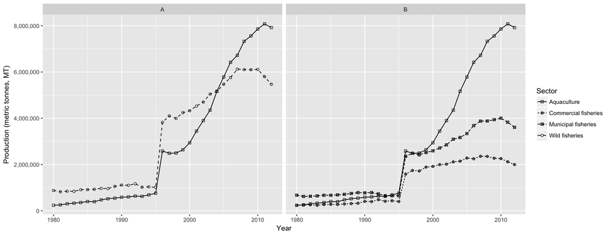

Fisheries in the Philippines face a diverse array of threats, including overexploitation, illegal and destructive fishing, habitat loss, coastal pollution, and climate change. Some of these forces already receive considerable attention. Although national regulations ban fishing by the commercial fleet in municipal waters, illegal encroachment is believed to be rampant, with scaled-down commercial vessels, referred to as *‘baby trawlers’* operating extensively in municipal waters (Palomares, M. L. D., and D. Pauly, 2010). Numerous destructive fishing practices also occur throughout the Philippines, including blast fishing, several destructive forms of trawling, and the use of poisonous and noxious substances such as cyanide. In 1993, the extent of damaged coral in the Santiago Island area of Luzon, Philippines was approximately 50%, with a moderate estimate of annual coral loss rate of 2.84% (Saila, Kocic, and McManus, 1993). The authors also provided a “worst case” estimate of 27.5% coral loss per year (13% blast fishing; 9.5% cyanide; 5% anchor damage), demonstrating the large uncertainty around the magnitude of destructive activities. Climate change is predicted to decrease fisheries productivity in the low to mid latitudes, including a projected ~10% decline in the Philippines by 2050 (Barange et al. 2014).

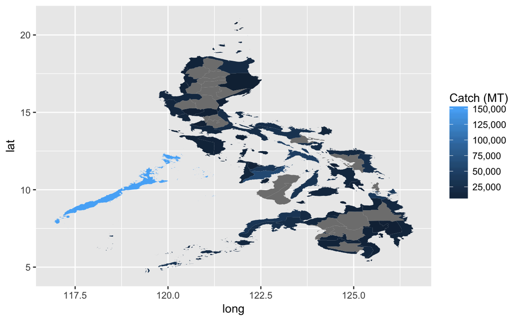

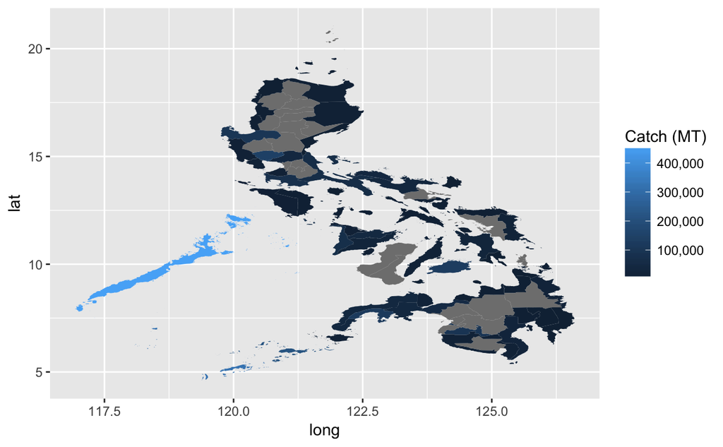

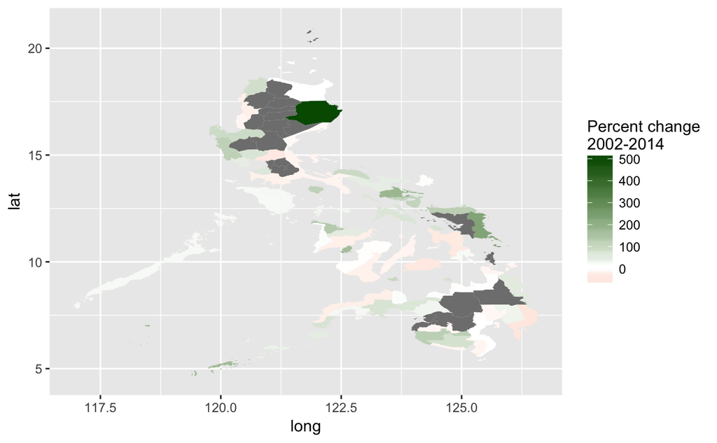

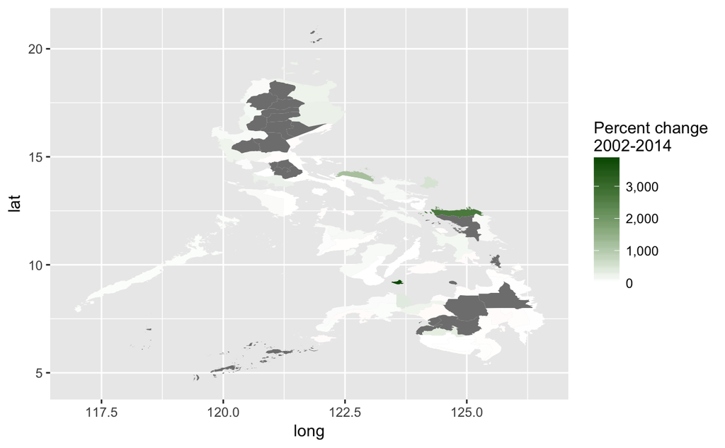

## Materials and Methods

Data for this analysis comes from several sources. Fishery catch data for both the municipal and commercial sectors was obtained from the CountrySTAT Philippines data portal. These data include time series of catch (MT) and value for 31 species items organized by region and province.

### Results

```
Call:
lm(formula = m1a_fmla, data = species_df)

Residuals:
     Min       1Q   Median       3Q      Max
-10.0774  -1.0000   0.1139   1.1347   7.0210

Coefficients:
                                   Estimate Std. Error t value Pr(>|t|)
(Intercept)                       3.499e+00  6.994e-02  50.024  < 2e-16 ***
aqua_harvest                      3.914e-06  1.446e-06   2.708  0.00678 **
culture_typeMussel               -1.195e-02  1.071e-01  -0.112  0.91113
culture_typeOyster                8.907e-02  4.713e-02   1.890  0.05882 .
culture_typeSeaweed               8.651e-02  4.368e-02   1.981  0.04763 *
province_nameAKLAN                1.186e+00  8.632e-02  13.743  < 2e-16 ***
province_nameALBAY                1.874e+00  8.747e-02  21.428  < 2e-16 ***
province_nameANTIQUE              1.280e+00  8.484e-02  15.090  < 2e-16 ***
province_nameAURORA               3.517e-01  8.536e-02   4.120 3.79e-05 ***
province_nameBASILAN              1.764e+00  8.671e-02  20.348  < 2e-16 ***
province_nameBATAAN               9.996e-01  8.604e-02  11.617  < 2e-16 ***
province_nameBATANGAS             1.616e+00  9.740e-02  16.587  < 2e-16 ***
province_nameBILIRAN              1.044e-01  8.610e-02   1.213  0.22529
province_nameBOHOL                1.315e+00  7.870e-02  16.710  < 2e-16 ***
province_nameBULACAN              1.802e-01  1.129e-01   1.596  0.11055
province_nameCAGAYAN              2.246e+00  8.492e-02  26.446  < 2e-16 ***
province_nameCAMARINES NORTE      2.453e+00  8.492e-02  28.879  < 2e-16 ***
province_nameCAMARINES SUR        2.544e+00  8.509e-02  29.903  < 2e-16 ***
province_nameCAMIGUIN            -5.175e-01  1.090e-01  -4.750 2.04e-06 ***
province_nameCAPIZ                2.741e+00  8.163e-02  33.573  < 2e-16 ***
province_nameCATANDUANES          1.332e+00  8.644e-02  15.404  < 2e-16 ***
province_nameCAVITE               8.380e-01  8.217e-02  10.199  < 2e-16 ***
province_nameCEBU                 2.757e+00  7.715e-02  35.739  < 2e-16 ***
province_nameCOMPOSTELA VALLEY    2.611e-01  8.124e-02   3.213  0.00131 **
province_nameDAVAO CITY          -2.043e-01  8.904e-02  -2.294  0.02178 *
province_nameDAVAO DEL NORTE     -6.342e-02  8.000e-02  -0.793  0.42793
province_nameDAVAO DEL SUR        1.311e+00  7.881e-02  16.634  < 2e-16 ***
province_nameDAVAO ORIENTAL       1.621e+00  8.169e-02  19.847  < 2e-16 ***
province_nameEASTERN SAMAR        2.050e+00  8.202e-02  24.997  < 2e-16 ***
province_nameGUIMARAS             5.181e-01  7.923e-02   6.540 6.21e-11 ***
province_nameILOCOS NORTE         5.603e-01  8.131e-02   6.891 5.61e-12 ***
```

[output cut: 36 more lines]

```
province_nameZAMBOANGA SIBUGAY    2.453e+00  8.457e-02  29.005  < 2e-16 ***
aqua_price                        9.695e-05  2.164e-05   4.480 7.48e-06 ***
aqua_harvest:culture_typeMussel   2.644e-06  1.003e-05   0.264  0.79204
aqua_harvest:culture_typeOyster   4.550e-06  8.439e-06   0.539  0.58975
aqua_harvest:culture_typeSeaweed  1.533e-06  2.165e-06   0.708  0.47910
culture_typeMussel:aqua_price     3.734e-05  6.647e-05   0.562  0.57424
culture_typeOyster:aqua_price    -9.535e-05  2.220e-05  -4.296 1.74e-05 ***
culture_typeSeaweed:aqua_price   -7.186e-05  2.382e-05  -3.016  0.00256 **
---
Signif. codes:  0 ‘***’ 0.001 ‘**’ 0.01 ‘*’ 0.05 ‘.’ 0.1 ‘ ’ 1

Residual standard error: 1.717 on 53688 degrees of freedom
  (13643 observations deleted due to missingness)
Multiple R-squared:  0.2694,    Adjusted R-squared:  0.2684
F-statistic: 267.6 on 74 and 53688 DF,  p-value: < 2.2e-16
```